# IS 4487 Assignment 5: Exploratory Data Analysis (EDA) with Stakeholder Framing

In this assignment, you will:

- Load and explore a hotel bookings dataset
- Identify stakeholder needs and frame your analysis around business goals
- Practice data summarization and visualization
- Draw insights that could lead to actionable business recommendations

## Why This Matters

These skills are essential for business majors and minors working in areas like marketing, operations, finance, or consulting. Understanding how to explore and communicate data-driven insights helps you make better decisions and contribute to real-world business outcomes.

## Dataset Description: Hotel Bookings

This dataset contains booking information for two types of hotels: a **city hotel** and a **resort hotel**. Each record corresponds to a single booking and includes various details about the reservation, customer demographics, booking source, and whether the booking was canceled.

**Source**: [GitHub - TidyTuesday: Hotel Bookings](https://github.com/rfordatascience/tidytuesday/blob/master/data/2020/2020-02-11/readme.md)

### Key Use Cases

- Understand customer booking behavior
- Explore factors related to cancellations
- Segment guests based on booking characteristics
- Compare city vs. resort hotel performance

### Data Dictionary

| Variable | Type | Description |
| --- | --- | --- |
| `hotel` | character | Hotel type: City or Resort |
| `is_canceled` | integer | 1 = Canceled, 0 = Not Canceled |
| `lead_time` | integer | Days between booking and arrival |
| `arrival_date_year` | integer | Year of arrival |
| `arrival_date_month` | character | Month of arrival |
| `stays_in_weekend_nights` | integer | Nights stayed on weekends |
| `stays_in_week_nights` | integer | Nights stayed on weekdays |
| `adults` | integer | Number of adults |
| `children` | integer | Number of children |
| `babies` | integer | Number of babies |
| `meal` | character | Type of meal booked |
| `country` | character | Country code of origin |
| `market_segment` | character | Booking source (e.g., Direct, Online TA) |
| `distribution_channel` | character | Booking channel used |
| `is_repeated_guest` | integer | 1 = Repeated guest, 0 = New guest |
| `previous_cancellations` | integer | Past booking cancellations |
| `previous_bookings_not_canceled` | integer | Past bookings not canceled |
| `reserved_room_type` | character | Initially reserved room type |
| `assigned_room_type` | character | Room type assigned at check-in |
| `booking_changes` | integer | Number of booking modifications |
| `deposit_type` | character | Deposit type (No Deposit, Non-Refund, etc.) |
| `agent` | character | Agent ID who made the booking |
| `company` | character | Company ID (if booking through company) |
| `days_in_waiting_list` | integer | Days on the waiting list |
| `customer_type` | character | Booking type: Contract, Transient, etc. |
| `adr` | float | Average Daily Rate (price per night) |
| `required_car_parking_spaces` | integer | Requested parking spots |
| `total_of_special_requests` | integer | Number of special requests made |
| `reservation_status` | character | Final status (Canceled, No-Show, Check-Out) |
| `reservation_status_date` | date | Date of the last status update |

This dataset is ideal for classification, segmentation, and trend analysis exercises.

## 1. Setup and Data Loading

Instructions:

- Import `pandas`, `seaborn`, and `matplotlib.pyplot`.
- Import data from the hotels dataset into a dataframe (in GitHub go to the DataSets folder and look for `hotels.csv`)
- Display the first few rows to confirm it loaded correctly.

```python
# Your code to import libraries and load data goes here
# 1
import pandas as pd
import seaborn as sns
import matplotlib.pyplot as plt

#2
url = "https://raw.githubusercontent.com/rfordatascience/tidytuesday/master/data/2020/2020-02-11/hotels.csv"
hotel_df = pd.read_csv(url)

#3
hotel_df.head()
```

|  | hotel | is_canceled | lead_time | arrival_date_year | arrival_date_month | arrival_date_week_number | arrival_date_day_of_month | stays_in_weekend_nights | stays_in_week_nights | adults | ... | deposit_type | agent | company | days_in_waiting_list | customer_type | adr | required_car_parking_spaces | total_of_special_requests | reservation_status | reservation_status_date |
| --- | --- | --- | --- | --- | --- | --- | --- | --- | --- | --- | --- | --- | --- | --- | --- | --- | --- | --- | --- | --- | --- |
| 0 | Resort Hotel | 0 | 342 | 2015 | July | 27 | 1 | 0 | 0 | 2 | ... | No Deposit | NaN | NaN | 0 | Transient | 0.0 | 0 | 0 | Check-Out | 2015-07-01 |
| 1 | Resort Hotel | 0 | 737 | 2015 | July | 27 | 1 | 0 | 0 | 2 | ... | No Deposit | NaN | NaN | 0 | Transient | 0.0 | 0 | 0 | Check-Out | 2015-07-01 |
| 2 | Resort Hotel | 0 | 7 | 2015 | July | 27 | 1 | 0 | 1 | 1 | ... | No Deposit | NaN | NaN | 0 | Transient | 75.0 | 0 | 0 | Check-Out | 2015-07-02 |
| 3 | Resort Hotel | 0 | 13 | 2015 | July | 27 | 1 | 0 | 1 | 1 | ... | No Deposit | 304.0 | NaN | 0 | Transient | 75.0 | 0 | 0 | Check-Out | 2015-07-02 |
| 4 | Resort Hotel | 0 | 14 | 2015 | July | 27 | 1 | 0 | 2 | 2 | ... | No Deposit | 240.0 | NaN | 0 | Transient | 98.0 | 0 | 1 | Check-Out | 2015-07-03 |

5 rows × 32 columns

## 2. Stakeholder and Business Context

### Business framing:

Every analysis should serve a decision-maker. Before you explore the data, identify who cares about hotel booking behavior and what they might want to know. Your analysis should be framed around those needs.

### In Your Response:

1. Who are the key stakeholders for this dataset?
2. What goals might each stakeholder have?
3. What is a clear, specific business problem statement that this data can help answer?

### ✍️ Your Response: 🔧

1. The key stakeholders include hotel management, revenue managers, marketing teams, and customer experience managers. Hotel management focuses on operations and occupancy, revenue managers monitor pricing and profitability, marketing teams target customer segments, and customer experience managers aim to improve guest satisfaction and loyalty. Each stakeholder relies on booking data to make informed decisions.
2. Hotel management wants to reduce cancellations and optimize room allocation. Revenue managers aim to maximize Average Daily Rate and identify high-value customers. Marketing teams focus on attracting profitable segments and encouraging repeat bookings, while customer experience managers seek to meet guest needs and enhance satisfaction.
3. Hotel management needs to understand factors affecting cancellations, guest behavior, and revenue patterns across city and resort hotels. This data can help identify high-risk bookings, guide pricing and marketing strategies, and improve operational decisions. The ultimate goal is to increase profitability and enhance the overall guest experience.

## 3. Explore Data Structure and Quality

### Business framing:

Before diving into analysis, analysts need to understand the shape and health of the data. Bad data leads to bad decisions.

### Do the following:

- Perform the following 3 checks to see the data quality:
  - Summary the data (e.g., `.info()`, `.describe()`)
  - Find the number of Null values
  - Find the number of duplicate row checks

```python
# Add code here 🔧
# 1
print("=== Data Info ===")
hotel_df.info()

print("n=== Summary Statistics ===")
hotel_df.describe(include='all')

#2
print("n=== Missing Values per Column ===")
missing_values = hotel_df.isnull().sum()
print(missing_values[missing_values > 0])

#3
duplicate_rows = hotel_df.duplicated().sum()
print(f"\nNumber of duplicate rows: {duplicate_rows}")
```

```
=== Data Info ===
<class 'pandas.core.frame.DataFrame'>
RangeIndex: 119390 entries, 0 to 119389
Data columns (total 32 columns):
 #   Column                          Non-Null Count   Dtype
---  ------                          --------------   -----
 0   hotel                           119390 non-null  object
 1   is_canceled                     119390 non-null  int64
 2   lead_time                       119390 non-null  int64
 3   arrival_date_year               119390 non-null  int64
 4   arrival_date_month              119390 non-null  object
 5   arrival_date_week_number        119390 non-null  int64
 6   arrival_date_day_of_month       119390 non-null  int64
 7   stays_in_weekend_nights         119390 non-null  int64
 8   stays_in_week_nights            119390 non-null  int64
 9   adults                          119390 non-null  int64
 10  children                        119386 non-null  float64
 11  babies                          119390 non-null  int64
 12  meal                            119390 non-null  object
 13  country                         118902 non-null  object
 14  market_segment                  119390 non-null  object
 15  distribution_channel            119390 non-null  object
 16  is_repeated_guest               119390 non-null  int64
 17  previous_cancellations          119390 non-null  int64
 18  previous_bookings_not_canceled  119390 non-null  int64
 19  reserved_room_type              119390 non-null  object
 20  assigned_room_type              119390 non-null  object
 21  booking_changes                 119390 non-null  int64
 22  deposit_type                    119390 non-null  object
 23  agent                           103050 non-null  float64
 24  company                         6797 non-null    float64
 25  days_in_waiting_list            119390 non-null  int64
 26  customer_type                   119390 non-null  object
 27  adr                             119390 non-null  float64
 28  required_car_parking_spaces     119390 non-null  int64
 29  total_of_special_requests       119390 non-null  int64
 30  reservation_status              119390 non-null  object
 31  reservation_status_date         119390 non-null  object
dtypes: float64(4), int64(16), object(12)
memory usage: 29.1+ MB
n=== Summary Statistics ===
n=== Missing Values per Column ===
children         4
country        488
agent        16340
company     112593
dtype: int64

Number of duplicate rows: 31994
```

### In Your Response:

1. What structural issues or problems did you find? (e.g., missing values, formatting problems)
2. What actions would you recommend to clean or prepare this dataset for use?

### ✍️ Your Response: 🔧

1. The dataset has several missing values, including children (4 missing), country (488 missing), agent (16,340 missing), and company (112,593 missing), which could affect analyses involving guest composition, booking sources, or corporate bookings. Additionally, there are 31,994 duplicate rows, which could inflate booking counts and skew cancellation or revenue statistics. Some columns, like reservation_status_date, are stored as objects rather than dates, which could complicate time-based analyses.
2. I would recommend removing duplicate rows to avoid double-counting bookings. Missing values in children and country could be imputed or filled with default values, while columns like agent and company could be treated as optional or analyzed separately due to the large number of missing entries. Finally, converting date columns to datetime objects and standardizing categorical variables will ensure accurate analysis and visualizations.

## 4. Univariate Analysis

### Business framing:

Hotels care about trends like average stay length, customer mix, and pricing. A good EDA starts with understanding single variables and their distribution.

### Do the following:

- Select at least 3 individual variables to explore
- Use plots and summary methods (e.g. info(), describe(), etc) to describe the distribution (hint: we are only looking at the values of one variable, so think of plots you've used in the past that DON'T compare 2 variables.)
- Focus on what matters from a business standpoint (e.g., pricing, cancellations, guest types)

```
count    119390.000000
mean        101.831122
std          50.535790
min          -6.380000
25%          69.290000
50%          94.575000
75%         126.000000
max        5400.000000
Name: adr, dtype: float64
```

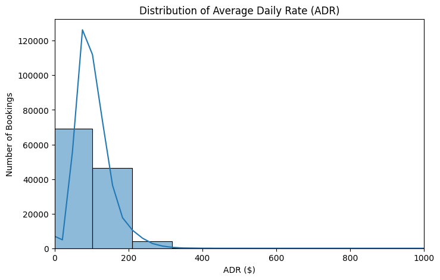

```python
# Your code for univariate analysis (e.g., plots, value counts) 🔧
# ADR
print(hotel_df['adr'].describe())

plt.figure(figsize=(8,5))
sns.histplot(hotel_df['adr'], bins=50, kde=True)
plt.title('Distribution of Average Daily Rate (ADR)')
plt.xlabel('ADR ($)')
plt.ylabel('Number of Bookings')
plt.xlim(0,1000)
plt.show()
```

```
count    119390.000000
mean          2.500302
std           1.908286
min           0.000000
25%           1.000000
50%           2.000000
75%           3.000000
max          50.000000
Name: stays_in_week_nights, dtype: float64
```

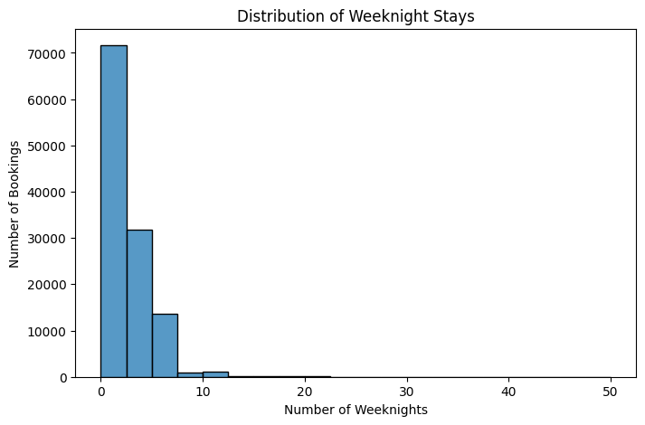

```python
# Stays in Week Nights
print(hotel_df['stays_in_week_nights'].describe())

plt.figure(figsize=(8,5))
sns.histplot(hotel_df['stays_in_week_nights'], bins=20, kde=False)
plt.title('Distribution of Weeknight Stays')
plt.xlabel('Number of Weeknights')
plt.ylabel('Number of Bookings')
plt.show()
```

```
is_canceled
0    75166
1    44224
Name: count, dtype: int64
```

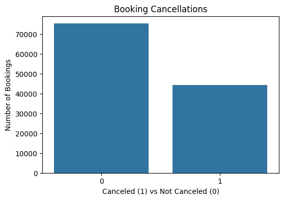

```python
# Booking Cancellations
print(hotel_df['is_canceled'].value_counts())

plt.figure(figsize=(6,4))
sns.countplot(x='is_canceled', data=hotel_df)
plt.title("Booking Cancellations")
plt.xlabel("Canceled (1) vs Not Canceled (0)")
plt.ylabel("Number of Bookings")
plt.show()
```

### In Your Response:

1. Variable 1 – What did you explore and what did you find?
2. Variable 2 – What did you explore and what did you find?
3. Variable 3 – What did you explore and what did you find?

### ✍️ Your Response: 🔧

Variable 1: I explored the distribution of the average daily rate (ADR) for bookings. The mean ADR is about 102, but there are some extreme values, including a minimum of -6.38 and a maximum of 5,400, indicating possible data entry errors or unusually high premium bookings. Most bookings are concentrated between 69 and 126, which reflects typical pricing patterns for the hotels.

Variable 2: I examined the number of weeknights guests stay at the hotel. Most bookings are short stays, with a median of 2 nights and 75% of stays lasting 3 nights or fewer. A few outliers extend up to 50 weeknights, which are rare but may represent long-term bookings or data anomalies.

Variable 3: I looked at the cancellation status of bookings to understand customer behavior. Out of 119,390 bookings, 44,224 were canceled, meaning roughly 37% of bookings did not materialize. This high cancellation rate highlights a significant risk to revenue and emphasizes the need for strategies to reduce cancellations.

## 5. Bivariate Analysis

### Business framing:

Stakeholders often ask: “What drives cancellations?” or “Do longer stays mean higher revenue?” Bivariate analysis helps you uncover those kinds of relationships.

### Do the following:

- Choose 2 relevant variable pairs (e.g., `lead_time` vs. `is_canceled`, or `adr` vs. `customer_type`)
- Use scatterplots, grouped bar plots, or boxplots to explore the relationships
- Interpret what these relationships could mean for the hotel business

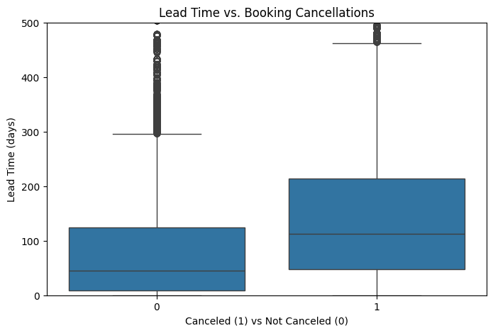

```python
# Your code to analyze variable relationships (e.g., scatterplots, grouped bars) 🔧
# Lead Time vs Cancellations

plt.figure(figsize=(8,5))
sns.boxplot(x='is_canceled', y='lead_time', data=hotel_df)
plt.title("Lead Time vs. Booking Cancellations")
plt.xlabel("Canceled (1) vs Not Canceled (0)")
plt.ylabel("Lead Time (days)")
plt.ylim(0,500)
plt.show()
```

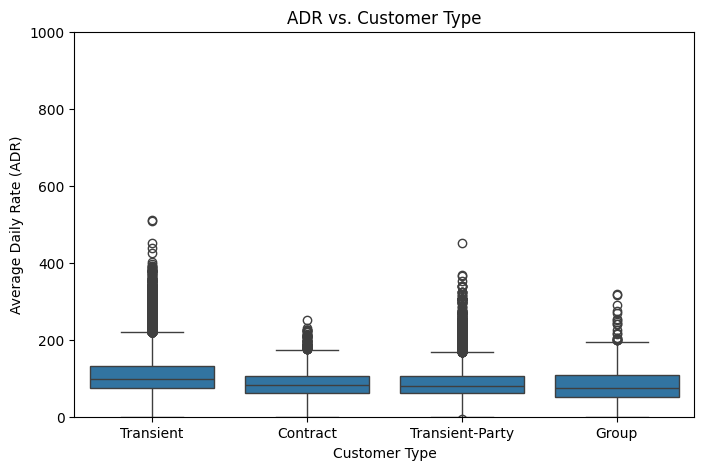

```python
# ADR vs Customer Type

plt.figure(figsize=(8,5))
sns.boxplot(x='customer_type', y='adr', data=hotel_df)
plt.title("ADR vs. Customer Type")
plt.xlabel("Customer Type")
plt.ylabel("Average Daily Rate (ADR)")
plt.ylim(0, 1000)
plt.show()
```

### In Your Response:

1. Relationship 1 – What did you analyze and what insights did you find?
2. Relationship 2 – What did you analyze and what insights did you find?

### ✍️ Your Response: 🔧

Relationship 1: Canceled bookings generally have higher lead times than non-canceled bookings. This suggests that guests booking far in advance are more likely to cancel, so management could implement policies like advance deposits or reminders to reduce revenue loss.

Relationship 2: Transient customers tend to have higher ADRs compared to contract or group bookings. This indicates that attracting more transient bookings could increase revenue, while contracts or group bookings may need volume-based pricing strategies.

## 6. Problem Complexity and Analytics Framing

### Business framing:

Let’s say you found a strong trend — maybe high lead times predict cancellations, or certain channels bring repeat guests. What kind of problem is this?

- Choose one insight from your earlier analysis
- Reflect on:
  - What type of complexity this problem represents (e.g., variety, volume, variability)
  - What kind of analytics would help solve or explain it (descriptive, diagnostic, predictive, prescriptive)

### In Your Response:

1. What was your selected insight?
2. What kind of complexity does it involve?
3. What type of analytics would help, and why?

### ✍️ Your Response: 🔧

1. Bookings with longer lead times are more likely to be canceled, indicating that the timing of a reservation is a strong predictor of cancellation risk.
2. This problem involves variability because not all long-lead bookings cancel. Customer behavior varies based on personal circumstances, booking type, or other factors. There is also variety, as cancellations may differ across customer types, hotels, or market segments.
3. Predictive analytics would be most helpful to model the likelihood of a booking being canceled based on lead time and other factors. This allows hotel management to forecast cancellations, take proactive measures, and optimize revenue. Descriptive analytics can summarize current cancellation patterns, but predictive models provide actionable guidance for future bookings.

## 7. Final Takeaways and Recommendations

### Business framing:

Imagine you’re preparing for a stakeholder meeting. What would you highlight from your findings?

- Identify your top 2–3 insights or patterns
- Connect each to a stakeholder need or business goal
- Make one recommendation based on the analysis

### In Your Response:

1. What patterns or trends stood out?
2. How do they connect to stakeholder goals?
3. What recommendation would you make based on this analysis?
4. How does this relate to your customized learning outcome you created in canvas?

### ✍️ Your Response: 🔧

1. High cancellations for long lead-time bookings. Guests who book far in advance are more likely to cancel. ADR varies by customer type. Transient guests generally pay higher rates than contract or group bookings. Most bookings are short stays. The majority of guests stay 1-3 weeknights, with very few long-term bookings.
2. Reducing cancellations addresses hotel management's goal of improving occupancy and revenue predictability. Understanding ADR by customer type helps revenue managers optimize pricing strategies and target high-value bookings. Insights on stay length guide operations and staffing teams in planning resources for peak occupancy days.
3. Implement a predictive model for cancellations based on lead time and customer type, paired with strategies like non-refundable deposits or reminder notifications. This would reduce lost revenue from cancellations while maintaining customer satisfaction and maximizing hotel profitability.
4. This assignment relates directly to my customized learning outcomes because it involves organizing and analyzing a large dataset to uncover patterns and trends. By exploring hotel bookings, I practiced data preparation, summarization, and visualization techniques that mirror tracking constituents, donors, or resources in real-world contexts. These skills support more informed decision-making, whether for engagement strategies or efficient resource and budget management.

## Submission Instructions

✅ **Before submitting:**

- Make sure all code cells are run and outputs are visible
- All markdown questions are answered thoughtfully
- Submit the assignment as an **HTML file** on Canvas

```python
!jupyter nbconvert --to html "assignment_05_eda.ipynb"
```